# Tutorial on Multiple Imputation using Chained Equations (MICE)

Univeristy of Michigan Biostatistics 699, Winter 2022

## `mice` (Multiple Imputation using Chained Equations)

- `mice()`: performs multiple imputations
- `parlmice()`: performs multiple imputations in parallel
- `with()`: (S3 method) fits a model to each imputed dataset
- `pool()`: appropriately combines across fitted models
- `tidy()`: (S3 method) summarizes fitted model

Also `ampute()` for artificially creating missingness in data (I haven’t used this before)

## MICE algorithm

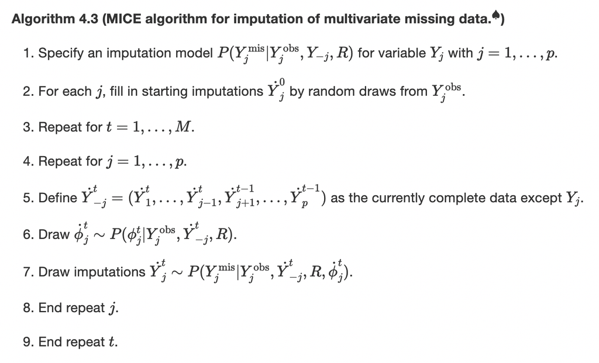

Algorithm 4.3 from *Flexible Imputation of Missing Data* by Stef van Buuren.

## Imputations models for normal-linear outcomes

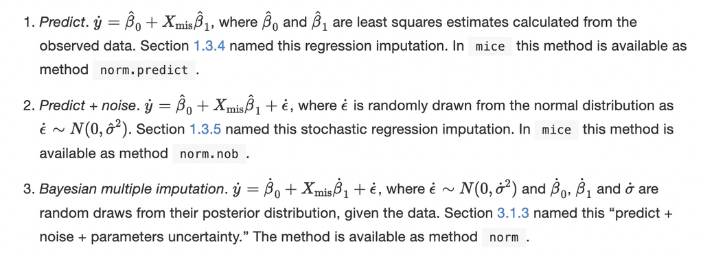

## Predictive mean matching

All-purpose, general imputation approach that works well for many types of data (continuous, binary, and categorical). Never imputes outside observed range of data.

1. Regress current variable \(Y\) against all other variables \(X\) using GLM using observations with observed \(Y\)
2. Calculate linear predictors (\(X\beta\)) for all observations, separated into two groups: those with observed \(Y\) and those missing \(Y\)
3. Identify \(d\) closest “donors”, i.e. linear predictors from observed group that are closest to linear predictors from missing group. Randomly select one such donor as imputation

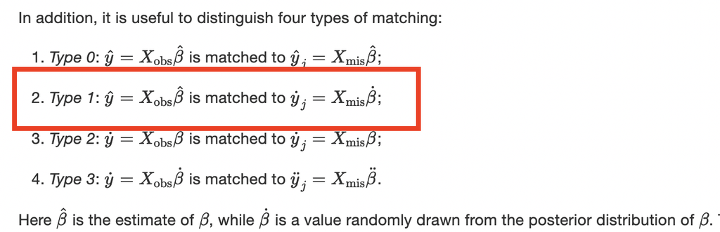

## Notes on `parlmice`

Easy way to speed up imputations by using multiple cores on your computer

```r
args(parlmice)
```

```
## function (data, m = 5, seed = NA, cluster.seed = NA, n.core = NULL,
##     n.imp.core = NULL, cl.type = "PSOCK", ...)
## NULL
```

As far as my testing and reading of the vigentte (https://www.gerkovink.com/parlMICE/Vignette_parlMICE.html) can tell, parlmice ignores the `m` (the number of imputed datasets) argument that one normally provides to mice(). Rather, number of imputations is determined by product of `n.core` (numbers of cores to use) and `n.imp.core` (number of imputations per core).

`n.core` should be less than value of `parallel::detectCores()`

## Chronic granulomatous disease data

From `?survival::cgd`:

> Data are from a placebo controlled trial of gamma interferon in chronic granulotomous disease (CGD). Contains the data on time to serious infections observed through end of study for each patient.

```r
library(survival)
cgd_first_obs <-
  cgd %>%
  # Keep only first event
  filter(enum == 1) %>%
  mutate(bmi = weight / (height / 100) ^2,
         nih = str_detect(center, "NIH")) %>%
  select(tstop, status, treat, sex, age, weight, height, bmi, inherit, propylac, nih)
```

```r
head(cgd_first_obs)
```

```
##   tstop status   treat    sex age weight height   bmi   inherit propylac   nih
## 1   219      1  rIFN-g female  12   62.0  147.0 28.69 autosomal        0 FALSE
## 2     8      1 placebo   male  15   47.5  159.0 18.79 autosomal        1 FALSE
## 3   382      0  rIFN-g   male  19   72.7  171.0 24.86  X-linked        1 FALSE
## 4   388      0  rIFN-g   male  12   34.0  142.0 16.86  X-linked        1 FALSE
## 5   246      1 placebo   male  17   52.7  162.5 19.96  X-linked        1  TRUE
## 6   364      0  rIFN-g female  44   45.0  153.3 19.15 autosomal        0 FALSE
```

Want to measure treatment effect on time to first serious infection, adjusting for sex, age, bmi, inheritance pattern, and prophylaxis

## About BMI…

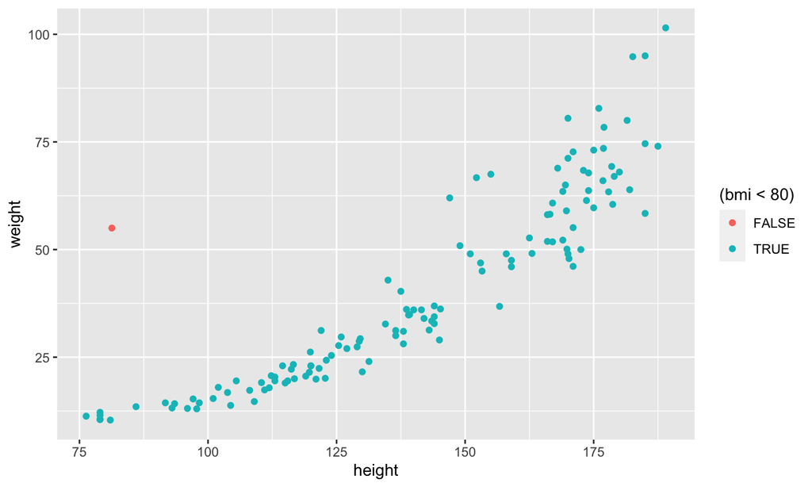

```r
ggplot(cgd_first_obs) +
  geom_point(aes(x = height, y = weight, color = (bmi < 80)))
```

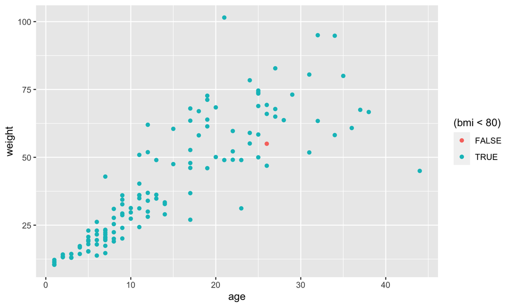

```r
ggplot(cgd_first_obs) +
  geom_point(aes(x = age, y = weight, color = (bmi < 80)))
```

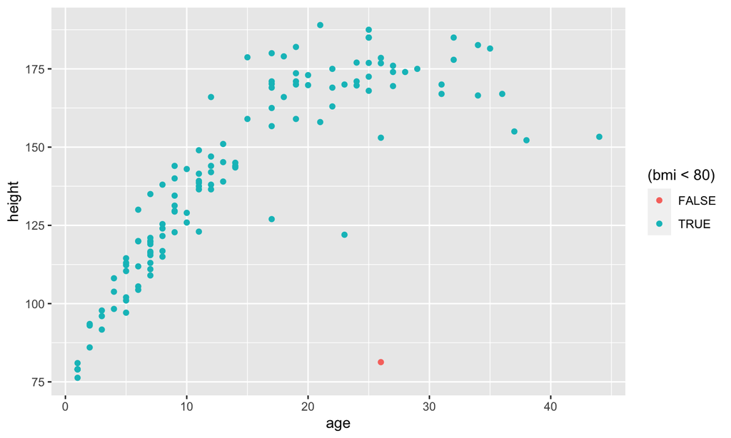

```r
ggplot(cgd_first_obs) +
  geom_point(aes(x = age, y = height, color = (bmi < 80)))
```

```r
coxph(Surv(tstop, status) ~ treat + sex + age + bmi + inherit + propylac, data = cgd_first_obs %>% filter(bmi < 80))
```

```
## Call:
## coxph(formula = Surv(tstop, status) ~ treat + sex + age + bmi +
##     inherit + propylac, data = cgd_first_obs %>% filter(bmi <
##     80))
##
##                   coef exp(coef) se(coef)    z     p
## treatrIFN-g      -1.18      0.31     0.35 -3.4 6e-04
## sexfemale        -0.17      0.85     0.51 -0.3  0.74
## age              -0.06      0.94     0.02 -2.6  0.01
## bmi               0.10      1.10     0.06  1.8  0.08
## inheritautosomal  0.26      1.29     0.41  0.6  0.53
## propylac         -0.34      0.71     0.42 -0.8  0.42
##
## Likelihood ratio test=20  on 6 df, p=0.003
## n= 127, number of events= 44
```

```r
coxph(Surv(tstop, status) ~ treat + sex + age + bmi + inherit + propylac, data = cgd_first_obs)
```

```
## Call:
## coxph(formula = Surv(tstop, status) ~ treat + sex + age + bmi +
##     inherit + propylac, data = cgd_first_obs)
##
##                   coef exp(coef) se(coef)    z     p
## treatrIFN-g      -1.10      0.33     0.34 -3.2 0.001
## sexfemale        -0.35      0.70     0.50 -0.7 0.483
## age              -0.04      0.96     0.02 -1.9 0.053
## bmi               0.01      1.01     0.02  0.4 0.668
## inheritautosomal  0.44      1.55     0.40  1.1 0.274
## propylac         -0.40      0.67     0.42 -1.0 0.338
##
## Likelihood ratio test=17  on 6 df, p=0.01
## n= 128, number of events= 44
```

```r
# set to missing the strange value of height
cgd_first_obs <-
  cgd_first_obs %>%
  mutate(height =
           case_when(bmi < 80 ~ height,
                     TRUE ~ NA_real_),
         bmi = weight / (height / 100) ^2)
```

```r
# no missingness (except that one strange height)
full_model <-
  coxph(Surv(tstop, status) ~ treat + sex + age + bmi + inherit + propylac, data = cgd_first_obs)

full_coefs <-
  tidy(full_model, conf.int = T) %>%
  select(term, estimate, conf.low, conf.high) %>%
  mutate(approach = "full")

full_coefs %>%
  mutate(across(where(is.numeric), ~formatC(.x, format = "f", digits = 3))) %>%
  kable()
```

| term | estimate | conf.low | conf.high | approach |
| --- | --- | --- | --- | --- |
| treatrIFN-g | -1.182 | -1.861 | -0.504 | full |
| sexfemale | -0.168 | -1.167 | 0.831 | full |
| age | -0.060 | -0.107 | -0.014 | full |
| bmi | 0.100 | -0.012 | 0.211 | full |
| inheritautosomal | 0.257 | -0.552 | 1.065 | full |
| propylac | -0.340 | -1.170 | 0.489 | full |

## Artificially induce missingness under three mechanisms

### MCAR

Percentages of missingness as follows:

- 20% of height (and therefore BMI);
- 25% of inheritance pattern;
- 25% of treat

## Artificially induce missingness under three mechanisms

### MAR

Percentages of missingness as follows:

- 20% of height (and corresponding BMI) (same as MCAR)
- 58% of inheritance in women and 17% of inheritance in men (yields overall 25% missingness)
- 84% of treat at NIH centers and 10% of treat at non-NIH centers (yields overall 25% missingness)

## Artificially induce missingness under three mechanisms

### NMAR

Percentages of missingness as follows:

- 20% of height (and corresponding BMI) (same as MCAR)
- 5% of inheritance pattern when inheritance is autosomal and 35% of when inheritance is X-linked (yields overall 25% missingness)
- 84% of treat at NIH centers and 10% of treat at non-NIH centers (yields overall 25% missingness) (same as MAR, but don’t adjust for center in the imputation model)

## Imputation methods

- Complete-case (CC) analysis: only analyze subjects with complete data for all predictors of interest
- Single Imputation (SI): single imputed dataset using predictive mean matching for missing continuous variables and logistic regression for missing binary variables
- Multiple Imputation (MI): multiple imputed dataset using predictive mean matching for missing continuous variables and logistic regression for missing binary variables

## `mice`, MCAR

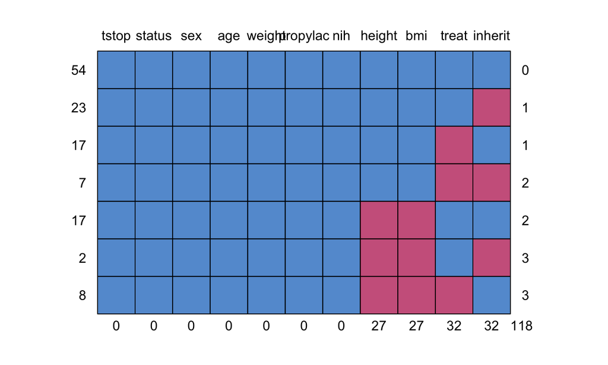

```
##    tstop status sex age weight propylac nih height bmi treat inherit
## 54     1      1   1   1      1        1   1      1   1     1       1   0
## 23     1      1   1   1      1        1   1      1   1     1       0   1
## 17     1      1   1   1      1        1   1      1   1     0       1   1
## 7      1      1   1   1      1        1   1      1   1     0       0   2
## 17     1      1   1   1      1        1   1      0   0     1       1   2
## 2      1      1   1   1      1        1   1      0   0     1       0   3
## 8      1      1   1   1      1        1   1      0   0     0       1   3
##        0      0   0   0      0        0   0     27  27    32      32 118
```

```r
permute_true_false <-
  function(n, prob) {
    if(is.logical(n)) {
      # n can be a vector of trues and falses
      result = rep(F, length(n))
      result[n] = sample(c(rep(T, round(prob*sum(n))),rep(F, sum(n) - round(prob*sum(n))) ))
    } else if(length(n) == 1 && n%%1 == 0) {
      # otherwise n should be a single integer
      result = sample(c(rep(T, round(prob*n)),rep(F, n - round(prob*n)) ))
    } else {stop("'n' must be a vector of logicals or a single integer")}
    result
  }

set.seed(1)
cgd_first_obs_mcar <-
  cgd_first_obs %>%
  mutate(
    # If TRUE, then keep it; otherwise it will be missing
    height = case_when(
      permute_true_false(n(), 0.8) ~ height),
    inherit = case_when(
      permute_true_false(n(), 0.75) ~ inherit),
    treat = case_when(
      permute_true_false(n(), 0.75) ~ treat),
    bmi = weight / (height / 100) ^2)

md.pattern(cgd_first_obs_mcar)
```

```r
# do a dry run of mice to prefill and then edit mice arguments
init = mice(cgd_first_obs_mcar, m = 1, max = 0, print = F);
method = init$meth;
method;
```

```
##    tstop   status    treat      sex      age   weight   height      bmi
##       ""       "" "logreg"       ""       ""       ""    "pmm"    "pmm"
##  inherit propylac      nih
## "logreg"       ""       ""
```

```r
# Formulas for derived variables;
method["bmi"] =
  "~I(weight / (height / 100) ^2)";
method;
```

```
##                            tstop                           status
##                               ""                               ""
##                            treat                              sex
##                         "logreg"                               ""
##                              age                           weight
##                               ""                               ""
##                           height                              bmi
##                            "pmm" "~I(weight / (height / 100) ^2)"
##                          inherit                         propylac
##                         "logreg"                               ""
##                              nih
##                               ""
```

```r
predictorMatrix = init$pred;

predictorMatrix
```

```
##          tstop status treat sex age weight height bmi inherit propylac nih
## tstop        0      1     1   1   1      1      1   1       1        1   1
## status       1      0     1   1   1      1      1   1       1        1   1
## treat        1      1     0   1   1      1      1   1       1        1   1
## sex          1      1     1   0   1      1      1   1       1        1   1
## age          1      1     1   1   0      1      1   1       1        1   1
## weight       1      1     1   1   1      0      1   1       1        1   1
## height       1      1     1   1   1      1      0   1       1        1   1
## bmi          1      1     1   1   1      1      1   0       1        1   1
## inherit      1      1     1   1   1      1      1   1       0        1   1
## propylac     1      1     1   1   1      1      1   1       1        0   1
## nih          1      1     1   1   1      1      1   1       1        1   0
```

```r
# Don't use bmi (a derived variable) to predict height (its ingredient):
predictorMatrix[ "height", "bmi"] = 0;
# Don't use ingredients of derived variables to predict anything else:
predictorMatrix[,c("height", "weight")] = 0;
predictorMatrix["height", "weight"] = 1;
predictorMatrix["weight", "height"] = 1;
# Ensure derived variables depend only on ingredients
predictorMatrix["bmi",] = 0;
predictorMatrix["bmi", c("weight", "height")] = 1;

predictorMatrix
```

```
##          tstop status treat sex age weight height bmi inherit propylac nih
## tstop        0      1     1   1   1      0      0   1       1        1   1
## status       1      0     1   1   1      0      0   1       1        1   1
## treat        1      1     0   1   1      0      0   1       1        1   1
## sex          1      1     1   0   1      0      0   1       1        1   1
## age          1      1     1   1   0      0      0   1       1        1   1
## weight       1      1     1   1   1      0      1   1       1        1   1
## height       1      1     1   1   1      1      0   0       1        1   1
## bmi          0      0     0   0   0      1      1   0       0        0   0
## inherit      1      1     1   1   1      0      0   1       0        1   1
## propylac     1      1     1   1   1      0      0   1       1        0   1
## nih          1      1     1   1   1      0      0   1       1        1   0
```

```r
visitSequence = init$visitSequence;

visitSequence
```

```
##  [1] "tstop"    "status"   "treat"    "sex"      "age"      "weight"
##  [7] "height"   "bmi"      "inherit"  "propylac" "nih"
```

```r
visitSequence = c(c("height", "bmi"),setdiff(visitSequence, c("height", "bmi")));

visitSequence
```

```
##  [1] "height"   "bmi"      "tstop"    "status"   "treat"    "sex"
##  [7] "age"      "weight"   "inherit"  "propylac" "nih"
```

```r
n_mi_chain_per_core = 2;#1;#
n_cores = 5; # should be < then value of parallel::detectCores()
n_mi_chain = n_mi_chain_per_core * n_cores;
# Total number of imputed datasets will be n_mi_chain_per_core * n_cores
n_iter =  30;#10;#

cgd_first_obs_mcar_imputed =
  parlmice(cgd_first_obs_mcar,
           predictorMatrix = predictorMatrix,
           method = method,
           visitSequence = visitSequence,
           maxit = n_iter,
           printFlag = T,
           n.imp.core = n_mi_chain_per_core,
           cluster.seed = 1,
           n.core = n_cores,
           cl.type = "FORK")

mcar_mi_coefs <-
  with(cgd_first_obs_mcar_imputed, coxph(Surv(tstop, status) ~ treat + sex + age + bmi + inherit + propylac)) %>%
  pool() %>%
  tidy(conf.int = T) %>%
  select(term, estimate, conf.low, conf.high) %>%
  mutate(approach = "mcar_mi")

mcar_si_coefs <-
  coxph(Surv(tstop, status) ~ treat + sex + age + bmi + inherit + propylac,
        data = complete(cgd_first_obs_mcar_imputed, 1)) %>%
  tidy(conf.int = T) %>%
  select(term,  estimate, conf.low, conf.high) %>%
  mutate(approach = "mcar_si")

mcar_cc_coefs <-
  coxph(Surv(tstop, status) ~ treat + sex + age + bmi + inherit + propylac,
        data = cgd_first_obs_mcar) %>%
  tidy(conf.int = T) %>%
  select(term, estimate, conf.low, conf.high) %>%
  mutate(approach = "mcar_cc")
```

## Comparison of MCAR results

```r
# Stack all imputed datasets
complete(cgd_first_obs_mcar_imputed, "long", include = T) %>%
  # add the actual dataset for comparison
  bind_rows(cgd_first_obs %>% select(colnames(.)) %>%
              mutate(.imp = -1)) %>%
  # group by type of data
  mutate(.imp_category =
           case_when(.imp == -1 ~ "1full",
                     .imp == 0  ~ "2obs",
                     .imp > 0 ~ "3imp")) %>%
  group_by(.imp_category) %>%
  summarize(median_bmi = median(bmi, na.rm = T),
            upperq_bmi = quantile(bmi, p = 0.75, na.rm = T),
            meanrIFNg = mean(treat == "rIFN-g", na.rm = T),
            mean_autosomal= mean(inherit == "autosomal", na.rm = T))
```

```
## # A tibble: 3 × 5
##   .imp_category median_bmi upperq_bmi meanrIFNg mean_autosomal
##   <chr>              <dbl>      <dbl>     <dbl>          <dbl>
## 1 1full               17.8       21.0     0.492          0.328
## 2 2obs                18.3       21.0     0.469          0.323
## 3 3imp                18.2       21.0     0.476          0.327
```

## Comparison of MCAR results

### Width of confidence intervals printed

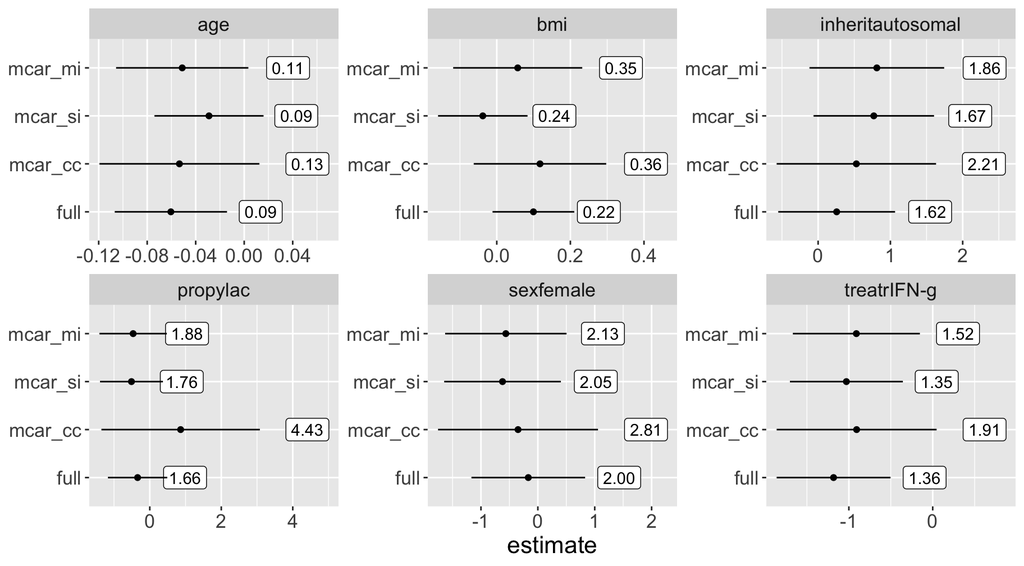

## `mice`, MAR

```r
set.seed(1)
cgd_first_obs_mar <-
  cgd_first_obs %>%
  mutate(
    # This is stil MCAR as before
    height = case_when(
      permute_true_false(n(), 0.8) ~ height),
    # This is MAR as long as we condition on sex in the imputation
    inherit = case_when(
      sex == "female" & permute_true_false(sex == "female", 0.4) ~ inherit,
      sex == "male" & permute_true_false(sex == "male", 0.83) ~ inherit),
    # This is MAR as long as we condition on nih in the imputation
    treat = case_when(
      nih & permute_true_false(nih, 0.16) ~ treat,
      !nih & permute_true_false(!nih, 0.90)  ~ treat),
    bmi = weight / (height / 100) ^2)

cgd_first_obs_mar_imputed =
  parlmice(cgd_first_obs_mar,
           predictorMatrix = predictorMatrix,
           method = method,
           visitSequence = visitSequence,
           maxit = n_iter,
           printFlag = T,
           n.imp.core = n_mi_chain_per_core,
           cluster.seed = 1,
           n.core = n_cores,
           cl.type = "FORK")
```

```r
mar_cc_coefs <-
  coxph(Surv(tstop, status) ~ treat + sex + age + bmi + inherit + propylac,
        data = cgd_first_obs_mar) %>%
  tidy(conf.int = T) %>%
  select(term, estimate, conf.low, conf.high) %>%
  mutate(approach = "mar_cc")
```

## Comparison of MAR results

```r
complete(cgd_first_obs_mar_imputed, "long", include = T) %>%
  bind_rows(cgd_first_obs %>% select(colnames(.)) %>%
              mutate(.imp = -1)) %>%
  mutate(.imp_category =
           case_when(.imp == -1 ~ "1full",
                     .imp == 0  ~ "2obs",
                     .imp > 0 ~ "3imp")) %>%
  group_by(.imp_category) %>%
  summarize(median_bmi = median(bmi, na.rm = T),
            upperq_bmi = quantile(bmi, p = 0.75, na.rm = T),
            meanrIFNg = mean(treat == "rIFN-g", na.rm = T),
            mean_autosomal= mean(inherit == "autosomal", na.rm = T))
```

```
## # A tibble: 3 × 5
##   .imp_category median_bmi upperq_bmi meanrIFNg mean_autosomal
##   <chr>              <dbl>      <dbl>     <dbl>          <dbl>
## 1 1full               17.8       21.0     0.492          0.328
## 2 2obs                18.3       21.0     0.510          0.260
## 3 3imp                18.2       21.0     0.566          0.317
```

## Comparison of MAR results

### Width of confidence intervals printed

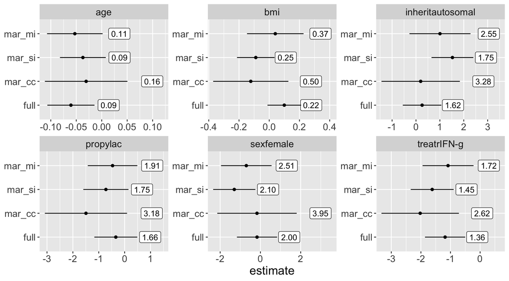

## `mice`, NMAR

```r
set.seed(1)
cgd_first_obs_nmar <-
  cgd_first_obs %>%
  mutate(
    # This is stil MCAR as before
    height = case_when(
      permute_true_false(n(), 0.8) ~ height),
    # This is NMAR: the probability of missingness depends on the missing value
    inherit = case_when(
      inherit == "autosomal" & permute_true_false(inherit == "autosomal", 0.95) ~ inherit,
      inherit == "X-linked" & permute_true_false(inherit == "X-linked", 0.65) ~ inherit),
    # This is the same as above but will be NMAR when we don't include
    # nih in the imputation step
    treat = case_when(
      nih & permute_true_false(nih, 0.16) ~ treat,
      !nih & permute_true_false(!nih, 0.90)  ~ treat),
    bmi = weight / (height / 100) ^2)

# If we don't adjust for nih in our imputation models, then
# the mar scenario becomes an nmar scenario:
predictorMatrix_nmar = predictorMatrix
predictorMatrix_nmar[,"nih"] = 0

cgd_first_obs_nmar_imputed =
  parlmice(cgd_first_obs_nmar,
           predictorMatrix = predictorMatrix_nmar,
           method = method,
           visitSequence = visitSequence,
           maxit = n_iter,
           printFlag = T,
           n.imp.core = n_mi_chain_per_core,
           cluster.seed = 1,
           n.core = n_cores,
           cl.type = "FORK")

# Compare to scenario where we *do* adjust for nih
cgd_first_obs_mar_imputed =
  parlmice(cgd_first_obs_nmar,
           predictorMatrix = predictorMatrix,
           method = method,
           visitSequence = visitSequence,
           maxit = n_iter,
           printFlag = T,
           n.imp.core = n_mi_chain_per_core,
           cluster.seed = 1,
           n.core = n_cores,
           cl.type = "FORK")
```

## Comparison of NMAR results

```r
complete(cgd_first_obs_nmar_imputed, "long", include = T) %>%
  bind_rows(cgd_first_obs %>% select(colnames(.)) %>%
              mutate(.imp = -1)) %>%
  mutate(.imp_category =
           case_when(.imp == -1 ~ "1full",
                     .imp == 0  ~ "2obs",
                     .imp > 0 ~ "3imp")) %>%
  group_by(.imp_category) %>%
  summarize(median_bmi = median(bmi, na.rm = T),
            upperq_bmi = quantile(bmi, p = 0.75, na.rm = T),
            meanrIFNg = mean(treat == "rIFN-g", na.rm = T),
            mean_autosomal= mean(inherit == "autosomal", na.rm = T))
```

```
## # A tibble: 3 × 5
##   .imp_category median_bmi upperq_bmi meanrIFNg mean_autosomal
##   <chr>              <dbl>      <dbl>     <dbl>          <dbl>
## 1 1full               17.8       21.0     0.492          0.328
## 2 2obs                18.3       21.0     0.458          0.417
## 3 3imp                18.2       21.0     0.457          0.377
```

```r
complete(cgd_first_obs_mar_imputed, "long", include = T) %>%
  bind_rows(cgd_first_obs %>% select(colnames(.)) %>%
              mutate(.imp = -1)) %>%
  mutate(.imp_category =
           case_when(.imp == -1 ~ "1full",
                     .imp == 0  ~ "2obs",
                     .imp > 0 ~ "3imp")) %>%
  group_by(.imp_category) %>%
  summarize(median_bmi = median(bmi, na.rm = T),
            upperq_bmi = quantile(bmi, p = 0.75, na.rm = T),
            meanrIFNg = mean(treat == "rIFN-g", na.rm = T),
            mean_autosomal= mean(inherit == "autosomal", na.rm = T))
```

```
## # A tibble: 3 × 5
##   .imp_category median_bmi upperq_bmi meanrIFNg mean_autosomal
##   <chr>              <dbl>      <dbl>     <dbl>          <dbl>
## 1 1full               17.8       21.0     0.492          0.328
## 2 2obs                18.3       21.0     0.458          0.417
## 3 3imp                18.2       21.0     0.395          0.379
```

## Comparison of NMAR results

### Width of confidence intervals printed

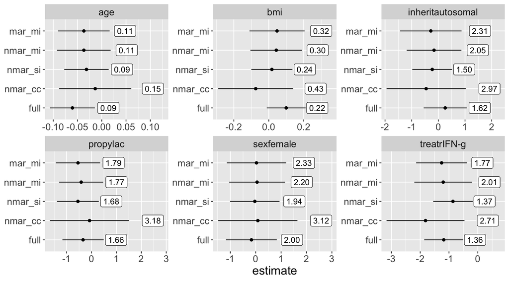

## Take aways

- Comparison in terms of ‘presumed information’ (information you think you have) \(\mathrm{SI}\succ\mathrm{MI}\succ\mathrm{CC}\), which means that uncertainty will *seem* to be smallest under SI, because it is essentially filling in data
- But goal isn’t to identify most likely values of missing data (otherwise we wouldn’t be adding noise to imputations); so comparing distribution of imputed to observed is of limited utility
- We conditioned on the outcome, which is generally the right thing to do. But different opinions exist on how to condition on survival outcome: condition on time directly, or log(time), or cumulative hazard (White, 2009; Beesley, 2021)

## References

Beesley, Lauren J., and Jeremy MG Taylor. “A stacked approach for chained equations multiple imputation incorporating the substantive model.” Biometrics 77 (2021): 1342-1354.

van Buuren, Stef, and Karin Groothuis-Oudshoorn. mice: Multivariate Imputation by Chained Equations in R. Journal of Statistical Software, 45 (2011): 1-67.

van Buuren, Stef. Flexible imputation of missing data. CRC press, 2018.

White Ian R., and Patrick Royston P. Imputing missing covariate values for the Cox model. Stat Med., 28 (2009): 1982-1998.